# Analyse de la Couverture Médiatique du Débat entre Kamala Harris et Donald Trump

Marie CHALLET

2024-09-20

# Introduction

Le débat sénatorial américain entre Kamala Harris et Donald Trump, qui s’est tenu dans la nuit du 10 au 11 septembre 2024, constitue un moment clé de la campagne électorale américaine. Ce débat est particulièrement important car il intervient à un moment crucial, où les deux candidats cherchent à convaincre des électeurs indécis tout en renforçant le soutien de leur base politique respective. L’objectif de cette analyse est d’évaluer la tonalité des articles médiatiques relatifs à ce débat, en déterminant si la couverture est positive, négative ou neutre pour chaque candidat.

Cette étude se concentre sur trois types de sources médiatiques : nationales, partisanes (pro-démocrates et pro-républicaines), et internationales, en offrant une analyse comparative et quantitative des tonalités associées à chaque candidat.

L’approche choisie repose donc sur trois axes complémentaires :

1. **Approche Nationale :**  
   Les médias américains comme *The Washington Post*, *USA Today*, *Associated Press*, *Fox News* et *Breitbart News* jouent un rôle central dans la formation de l’opinion publique nationale. Ces sources, malgré leurs biais politiques potentiels, offrent une perspective équilibrée et influencent largement les perceptions des électeurs américains. En analysant leur couverture, cette section vise à identifier les grandes tendances narratives et tonalités dominantes concernant le débat, en offrant une vue d’ensemble de l’impact médiatique national.
2. **Analyse Partisane :**  
   La presse américaine est souvent perçue à travers le prisme de ses préférences politiques. En comparant les articles de médias pro-démocrates (*Washington Post*, *CNN*) et pro-républicains (*Fox News*, *Breitbart News*), cette section cherche à mettre en lumière comment les biais éditoriaux peuvent influencer la présentation des candidats et, potentiellement, leurs perceptions auprès du public. Une telle analyse permet de décoder les différences narratives entre ces groupes de presse.
3. **Approche Internationale :**  
   Les médias internationaux, tels que *BBC News*, *The Guardian*, et *Reuters*, fournissent une perspective extérieure et globale sur le débat. Leurs angles d’analyse, moins centrés sur la politique intérieure américaine, peuvent refléter des préoccupations internationales et des perceptions différentes des candidats. L’analyse de ces sources permet de comprendre comment le débat est perçu en dehors des États-Unis et quelles en sont les répercussions internationales.

En combinant ces trois axes, l’étude permet de croiser des perspectives nationales, partisanes et internationales pour obtenir une vue d’ensemble nuancée de la couverture médiatique à l’égard des deux candidats. Cette approche holistique vise non seulement à exposer les différences de traitement médiatique en fonction des biais locaux et internationaux, mais aussi à évaluer leur impact potentiel sur l’opinion publique.

# 1. Provenance des Données

Cette analyse se concentre sur les articles publiés le lendemain du débat sénatorial entre Kamala Harris et Donald Trump, c’est-à-dire le 11 septembre 2024. Cette temporalité permet de saisir les premières réactions des médias, souvent essentielles pour influencer les perceptions des électeurs. Les articles du lendemain capturent ainsi la tonalité initiale des débats, avant que d’autres analyses et événements politiques ne viennent influencer la couverture médiatique. Ces articles capturent donc la réaction initiale des médias, qui est cruciale pour influencer les premières perceptions du public

Pour garantir une analyse équilibrée, j’ai sélectionné entre trois et six articles par source. Ce choix vise à offrir une couverture représentative, en réduisant les biais de sélection tout en garantissant une diversité de points de vue. Un trop grand nombre d’articles par source pourrait déséquilibrer l’analyse, tandis qu’un nombre trop faible risquerait de ne pas saisir toute la complexité des récits médiatiques.

### Articles Nationaux

Les sources nationales sélectionnées incluent :

- **The Washington Post** : washingtonpost.com
- **USA Today** : usatoday.com
- **Associated Press** : apnews.com
- **Fox News** : foxnews.com
- **Breitbart News** : breitbart.com

### Articles Partisans

Pour explorer les biais politiques, des médias à orientation démocrate et républicaine ont été inclus :

- **Pro-Démocrates :**
  - **The Washington Post** : washingtonpost.com
  - **CNN** : cnn.com
- **Pro-Républicains :**
  - **Fox News** : foxnews.com
  - **Breitbart News** : breitbart.com

### Articles Internationaux

Pour une perspective internationale, les articles proviennent des médias suivants :

- **BBC News** : bbc.com/news
- **The Guardian** : theguardian.com
- **Reuters** : reuters.com

Ces sources offrent un équilibre éditorial pour une compréhension plus globale des répercussions du débat.

# 2. Langue Choisie

L’analyse porte sur des articles en anglais pour garantir la cohérence des données. Cela permet d’utiliser efficacement les outils de traitement du langage naturel (NLP) optimisés pour cette langue. L’anglais est également la langue dominante dans les médias mondiaux, ce qui facilite l’inclusion de perspectives internationales.

Le rapport est rédigé en français pour refléter ma langue maternelle et faciliter l’interprétation des résultats. L’analyse des articles est réalisée avec le langage R, utilisant le package ‘udpipe’ pour le NLP, une approche efficace pour l’annotation des parties du discours et l’analyse de sentiment.

# 3. Méthode Utilisée

L’analyse textuelle a été réalisée à l’aide de NLP (Natural Language Processing), en utilisant le package udpipe en R. Les étapes clés incluent :

1. **Prétraitement des Textes**: nettoyage des articles pour retirer la ponctuation, les chiffres et les mots vides.
2. **Annotation des Textes** : utilisation de l’annotation grammaticale et du lemmatisation pour harmoniser les textes.
3. **Analyse de Sentiment** : application de plusieurs algorithmes de détection de sentiment (AFINN, Bing, NRC) pour identifier les émotions et sentiments associés à chaque candidat dans chaque article. J’ai choisi d’utiliser les lexiques AFINN, Bing, et NRC car ils offrent une complémentarité. AFINN est utile pour une mesure directe du sentiment, tandis que NRC permet d’identifier des émotions spécifiques, comme la colère ou la joie, qui sont pertinentes dans un débat aussi passionné. Bing, quant à lui, offre une classification binaire simple (positif/négatif), utile pour simplifier les résultats lorsque les autres modèles sont trop nuancés. Par exemple, un article de CNN intitulé “Harris shines in the debate, leaving Trump on the defensive” a été classé comme fortement positif par AFINN, avec un score de +4, tandis que l’outil Bing a détecté une dominance de termes positifs tels que “shine”, “defensive”, et “strong”.
4. **Comparaison par Catégorie** : comparaison des sentiments entre les différentes catégories (nationale, partisane, internationale).
5. **Visualisation des Résultats**: génération de barplots, boxplots, et radar charts pour représenter les sentiments de manière visuelle et intuitive.

### Justifications des choix méthodologiques et du code

**Choix des outils d’analyse (AFINN, Bing, NRC)** :

- AFINN a été choisi pour sa simplicité et son efficacité dans l’analyse de sentiments sur des textes courts, comme des articles de presse. Il permet une évaluation rapide des sentiments, ce qui est idéal dans un contexte où le temps est limité.
- Bing offre une approche binaire qui simplifie la classification des sentiments, ce qui est utile pour obtenir une vue d’ensemble rapide des articles. Sa capacité à attribuer des sentiments positifs ou négatifs aide à maintenir la clarté des résultats.
- NRC a été utilisé pour explorer non seulement les sentiments, mais aussi les émotions spécifiques (joie, colère, peur, etc.), ce qui enrichit l’analyse en ajoutant des nuances à la compréhension des sentiments exprimés dans la couverture médiatique.

**Méthodologie d’analyse des sentiments** :

L’utilisation de plusieurs lexiques permet de trianguler les résultats et d’assurer une robustesse de l’analyse. En confrontant les résultats issus d’AFINN, Bing et NRC, nous pouvons mieux saisir les sentiments complexes présents dans les articles. Le prétraitement des données a inclus la suppression des stop words et la lemmatisation, ce qui garantit que l’analyse ne soit pas influencée par des mots communs sans valeur sémantique. Cela permet de concentrer l’analyse sur les mots porteurs de sentiment.

**Visualisation des résultats** :

Les graphiques sont cruciaux pour la compréhension des résultats. En utilisant des barplots et des graphiques radar, j’ai pu illustrer les différences de perception de manière visuelle. Cela aide à communiquer des données complexes de manière intuitive, ce qui est essentiel pour des lecteurs non spécialisés.

### Limites de l’Analyse

Bien que l’approche NLP soit efficace pour analyser de grandes quantités de texte, certaines limites demeurent :

- **Interprétation contextuelle**: Les modèles peuvent avoir du mal à saisir le ton sarcastique, ironique, ou les doubles sens dans certains articles.
- **Biais dans les données** : Les modèles NLP peuvent hériter des biais présents dans les corpus de formation.
- **Tonalité neutre** : La détection des tonalités neutres est moins précise et pourrait altérer certaines conclusions.

# 4. Code Utilisé

L’ensemble du code utilisé pour l’analyse est écrit en R et est structuré autour de plusieurs fonctions permettant de charger les données, d’appliquer les modèles de sentiment, et de visualiser les résultats. Il comprend également des étapes pour normaliser les données, gérer les négations et modificateurs, et extraire les phrases mentionnant chaque candidat.

```r
# Chargement des bibliothèques nécessaires avec vérification
required_packages <- c(
  "readr",
  "dplyr",
  "stringr",
  "tm",
  "tokenizers",
  "udpipe",
  "ggplot2",
  "tidyr",
  "wordcloud",
  "reshape2",
  "syuzhet",
  "sentimentr",
  "textdata",
  "quanteda",
  "glmnet",
  "textstem",
  "purrr",
  "fmsb"
)

invisible(lapply(required_packages, function(pkg) {
  if (!require(pkg, character.only = TRUE)) {
    install.packages(pkg, dependencies = TRUE)
    library(pkg, character.only = TRUE)
  }
}))

# Fonction pour lire tous les fichiers .txt dans un dossier
read_text_files_from_folder <- function(folder_path) {
  text_files <- list.files(path = folder_path,
                           pattern = "\\.txt$",
                           full.names = TRUE)
  file_contents <- lapply(text_files, read_file)
  names(file_contents) <- basename(text_files)
  return(file_contents)
}

# Fonction principale pour charger et combiner les articles de chaque source
load_and_group_articles_by_source <- function(main_folder) {
  folders <- list.dirs(main_folder, full.names = TRUE, recursive = FALSE)
  all_sources_dfs <- list()

  for (folder in folders) {
    articles <- read_text_files_from_folder(folder)
    source_name <- basename(folder)
    df <- data.frame(
      id = names(articles),
      content = unlist(articles),
      source = source_name,
      stringsAsFactors = FALSE
    )

    all_sources_dfs[[source_name]] <- df
  }

  return(all_sources_dfs)
}

# Fonction pour organiser les sources par arc
organize_sources_by_arc <- function(sources_dfs, arc_type) {
  valid_sources <- switch(
    arc_type,
    "national" = c("Washington Post", "USA Today", "AP", "Fox News", "Breitbart"),
    "partisan" = c("Washington Post", "CNN", "Fox News", "Breitbart"),
    "international" = c("BBC", "The Guardian", "Reuters"),
    stop(
      "Arc type non reconnu. Veuillez choisir entre 'national', 'partisan', ou 'international'."
    )
  )
  # Filtrer les sources valides pour l'arc sélectionné
  return(sources_dfs[names(sources_dfs) %in% valid_sources])
}

# Fonction pour nettoyer le texte
clean_text <- function(text) {
  text %>%
    tolower() %>%
    removePunctuation() %>%
    removeNumbers() %>%
    removeWords(stopwords("en")) %>%
    stripWhitespace() %>%
    textstem::lemmatize_strings()
}

# Fonction pour annoter le texte avec udpipe et ajouter des métadonnées
annotate_text_with_metadata <- function(articles_df, model, arc_type) {
  annotations <- udpipe_annotate(model, x = articles_df$content, doc_id = articles_df$id)
  annotations <- as.data.frame(annotations)

  # Ajouter la colonne 'source' pour tous les arcs
  annotations <- merge(
    annotations,
    articles_df[, c("id", "source")],
    by.x = "doc_id",
    by.y = "id",
    all.x = TRUE
  )

  # Si arc_type est "partisan", ajouter la colonne 'political_orientation'
  if (arc_type == "partisan") {
    annotations <- merge(
      annotations,
      articles_df[, c("id", "political_orientation")],
      by.x = "doc_id",
      by.y = "id",
      all.x = TRUE
    )
  }

  return(annotations)
}

# Téléchargement et chargement du modèle udpipe
udpipe_model <- function(language = "english") {
  model_path <- paste0(language, "-ud-2.5-191206.udpipe")
  if (!file.exists(model_path)) {
    model <- udpipe_download_model(language = language)
    udpipe_load_model(file = model$file_model)
  } else {
    udpipe_load_model(file = model_path)
  }
}

# Fonction pour diviser les phrases en propositions avant d'annoter
split_into_propositions <- function(text) {
  # Utiliser tokenizers pour diviser en phrases
  sentences <- tokenizers::tokenize_sentences(text)

  # Utiliser une approche simple pour séparer par ponctuation forte
  propositions <- unlist(lapply(sentences, function(sentence) {
    tokenizers::tokenize_regex(sentence, pattern = "[,;:]")
  }))

  return(propositions)
}

# Mise à jour de la fonction preprocess_articles pour découper en propositions
preprocess_articles <- function(articles_df) {
  articles_df <- articles_df %>%
    mutate(cleaned_content = sapply(content, clean_text)) %>%
    mutate(propositions = sapply(cleaned_content, split_into_propositions))

  return(articles_df)
}

# Fonction principale pour traiter et prétraiter les articles par arc
process_and_preprocess_articles_by_arc <- function(main_folder, arc_type) {
  # Charger tous les articles
  grouped_articles_by_source <- load_and_group_articles_by_source(main_folder)

  # Filtrer les articles par arc avec organize_sources_by_arc
  filtered_articles <- organize_sources_by_arc(grouped_articles_by_source, arc_type)

  # Combiner les articles filtrés par arc
  combined_articles_df <- bind_rows(filtered_articles, .id = "source")

  # Ajouter l'orientation politique pour l'arc partisan
  if (arc_type == "partisan") {
    combined_articles_df <- combined_articles_df %>%
      mutate(
        political_orientation = case_when(
          source %in% c("Washington Post", "CNN") ~ "Pro-Démocrates",
          source %in% c("Fox News", "Breitbart") ~ "Pro-Républicains",
          TRUE ~ "Neutre"
        )
      )
  }

  # Prétraiter les articles combinés
  preprocessed_articles <- preprocess_articles(combined_articles_df)

  return(preprocessed_articles)
}

normalize_and_detect_candidates <- function(annotations) {
  annotations$lemma_lower <- tolower(annotations$lemma)

  annotations$candidat <- NA

  # Assigner les candidats en utilisant des mots spécifiques
  annotations$candidat[annotations$lemma_lower %in% c("trump", "donald", "donald trump") & annotations$upos == "PROPN"] <- "Trump"
  annotations$candidat[annotations$lemma_lower %in% c("harris", "kamala", "kamala harris") & annotations$upos == "PROPN"] <- "Harris"

  # Traiter les pronoms en fonction du contexte
  annotations$candidat[annotations$lemma_lower %in% c("he", "his", "him") & annotations$upos == "PRON"] <- "Trump"
  annotations$candidat[annotations$lemma_lower %in% c("she", "her") & annotations$upos == "PRON"] <- "Harris"

  # Rechercher les phrases contenant les deux candidats
  annotations <- annotations %>%
    group_by(doc_id, sentence_id) %>%
    mutate(candidats_detectes = list(unique(candidat[!is.na(candidat)]))) %>%
    ungroup()
```

```r
  # Associer les phrases à "Both" si les deux candidats sont mentionnés
  annotations$candidat_phrase <- case_when(
    map_lgl(annotations$candidats_detectes, ~ all(c("Trump", "Harris") %in% .)) ~ "Both",
    map_lgl(annotations$candidats_detectes, ~ "Trump" %in% .) ~ "Trump",
    map_lgl(annotations$candidats_detectes, ~ "Harris" %in% .) ~ "Harris",
    TRUE ~ NA_character_
  )

  return(annotations)
}


# Fonction pour filtrer et obtenir les phrases mentionnant un candidat
extract_candidate_phrases <- function(annotations, arc_type) {
  annotations_candidats <- annotations %>%
    filter(!is.na(candidat_phrase))

  # Si arc_type est "partisan", inclure 'political_orientation', sinon l'exclure
  if (arc_type == "partisan") {
    phrases_candidats <- annotations_candidats %>%
      group_by(doc_id,
               sentence_id,
               candidat_phrase,
               source,
               political_orientation) %>%
      summarise(phrase = paste(token, collapse = " "),
                sentiment_modifier = mean(sentiment_modifier),
                .groups = 'drop')
  } else {
    phrases_candidats <- annotations_candidats %>%
      group_by(doc_id, sentence_id, candidat_phrase, source) %>%
      summarise(
        phrase = paste(token, collapse = " "),
        sentiment_modifier = mean(sentiment_modifier),
        .groups = 'drop'
      )
  }

  return(phrases_candidats)
}


handle_negations_and_modifiers <- function(annotations) {
  negation_words <- c("not", "no", "never", "without")
  context_words <- c("claimed", "said", "argued", "stated")
  intensifiers <- c("very", "extremely", "highly", "incredibly")
  diminishers <- c("slightly", "somewhat", "rather", "little")

  annotations <- annotations %>%
    group_by(doc_id, sentence_id) %>%
    mutate(
      negation = cumsum(tolower(token) %in% negation_words) %% 2,
      context = ifelse(tolower(token) %in% context_words, 1, 0),
      sentiment_modifier = case_when(
        negation == 1 ~ -1,  # Inversion du sentiment en cas de négation
        tolower(token) %in% intensifiers ~ 2,  # Amplificateur
        tolower(token) %in% diminishers ~ 0.5,  # Réducteur
        context == 1 ~ 0.5,  # Modificateur basé sur le contexte
        TRUE ~ 1  # Pas de modificateur
      )
    ) %>%
    ungroup()

  return(annotations)
}

# Fonction pour l'analyse des sentiments avec plusieurs méthodes
analyze_sentiment <- function(phrases) {
  phrases %>%
    mutate(
      # Sentiment avec AFINN
      sentiment_afinn = get_sentiment(phrase, method = "afinn") * sentiment_modifier,

      # Sentiment avec Bing et NRC
      sentiment_bing = get_sentiment(phrase, method = "bing") * sentiment_modifier,
      sentiment_nrc = get_sentiment(phrase, method = "nrc") * sentiment_modifier,

      # Détection des émotions avec NRC
      emotions = map(phrase, get_nrc_sentiment)
    ) %>%
    unnest_wider(emotions) %>%
    mutate(across(c(positive, negative, anger:trust), ~ . * sentiment_modifier))
}


# Chemin vers le dossier contenant les sous-dossiers des différentes sources
main_folder <- "Sources"

# Traitement et prétraitement des articles pour chaque arc
national_articles <- process_and_preprocess_articles_by_arc(main_folder, "national")
partisan_articles <- process_and_preprocess_articles_by_arc(main_folder, "partisan")
international_articles <- process_and_preprocess_articles_by_arc(main_folder, "international")

# Utilisation de udpipe pour annoter les articles avec ajout des métadonnées
udpipe_eng <- udpipe_model("english")
annotations_national <- annotate_text_with_metadata(national_articles, udpipe_eng, "national")
annotations_partisan <- annotate_text_with_metadata(partisan_articles, udpipe_eng, "partisan")
annotations_international <- annotate_text_with_metadata(international_articles, udpipe_eng, "international")

# Normalisation et détection des candidats
annotations_national <- normalize_and_detect_candidates(annotations_national)
annotations_partisan <- normalize_and_detect_candidates(annotations_partisan)
annotations_international <- normalize_and_detect_candidates(annotations_international)

# Gestion des négations et des modificateurs de sentiment
annotations_national <- handle_negations_and_modifiers(annotations_national)
annotations_partisan <- handle_negations_and_modifiers(annotations_partisan)
annotations_international <- handle_negations_and_modifiers(annotations_international)

# Extraction des phrases mentionnant les candidats
phrases_national <- extract_candidate_phrases(annotations_national, "national")
phrases_partisan <- extract_candidate_phrases(annotations_partisan, "partisan")
phrases_international <- extract_candidate_phrases(annotations_international, "international")


# Analyse des sentiments
sentiment_national <- analyze_sentiment(phrases_national)
sentiment_partisan <- analyze_sentiment(phrases_partisan)
sentiment_international <- analyze_sentiment(phrases_international)

# Visualisations et représentations graphique

# Fonction pour générer un graphique radar des émotions avec couleurs personnalisées
plot_emotions_radar <- function(emotions_data, title) {
  emotion_cols <- c("anger", "anticipation", "disgust", "fear", "joy", "sadness", "surprise", "trust")

  # Agrégation des émotions par candidat
  radar_data <- emotions_data %>%
    group_by(candidat_phrase) %>%
    summarise(across(all_of(emotion_cols), mean, na.rm = TRUE))

  radar_data <- as.data.frame(radar_data)
  rownames(radar_data) <- radar_data$candidat_phrase
  radar_data <- radar_data[-which(rownames(radar_data) == "Both"), ]
  radar_data <- radar_data[, emotion_cols]

  # Pour le maximum et le minimum pour chaque axe (émotion)
  radar_data <- rbind(rep(1, 8), rep(0, 8), radar_data)

  # Définition des couleurs des candidats
  candidate_colors <- c("Trump" = "red", "Harris" = "blue")

  # Génération du graphique radar
  radarchart(radar_data, axistype = 1,
             pcol = candidate_colors,
             pfcol = alpha(candidate_colors, 0.5),
             plwd = 2,
             cglcol = "grey",
             cglty = 1,
             axislabcol = "black",
             title = title,
             caxislabels = seq(0, 1, 0.2),
             plty = 1)
  legend("topright", legend = names(candidate_colors), col = candidate_colors, lty = 1, bty = "n")
}
```

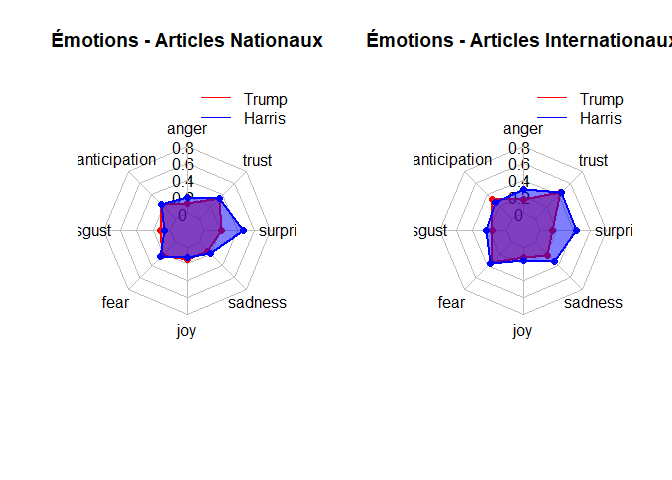

```r
par(mfrow = c(1, 2))  # 1 ligne, 2 colonnes
plot_emotions_radar(sentiment_national, "Émotions - Articles Nationaux")
plot_emotions_radar(sentiment_international, "Émotions - Articles Internationaux")
```

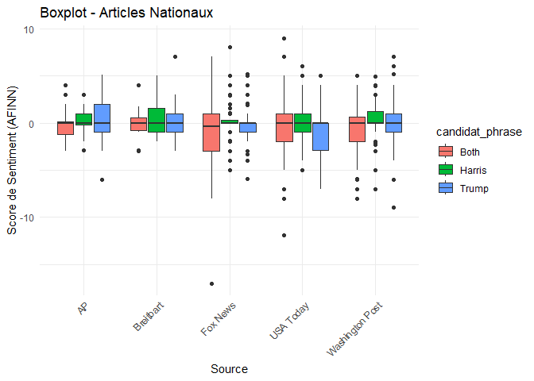

```r
par(mfrow = c(1, 1))

# Fonction pour créer un boxplot servant à visualiser la distribution des scores de sentiment
plot_sentiment_boxplot <- function(sentiment_data, title = "Boxplot de Sentiment") {
  ggplot(sentiment_data, aes(x = source, y = sentiment_afinn, fill = candidat_phrase)) +
    geom_boxplot() +
    labs(title = title, x = "Source", y = "Score de Sentiment (AFINN)") +
    theme_minimal() +
    theme(axis.text.x = element_text(angle = 45, hjust = 1))
}

# Application de la fonction pour chaque arc
plot_sentiment_boxplot(sentiment_national, "Boxplot - Articles Nationaux")
```

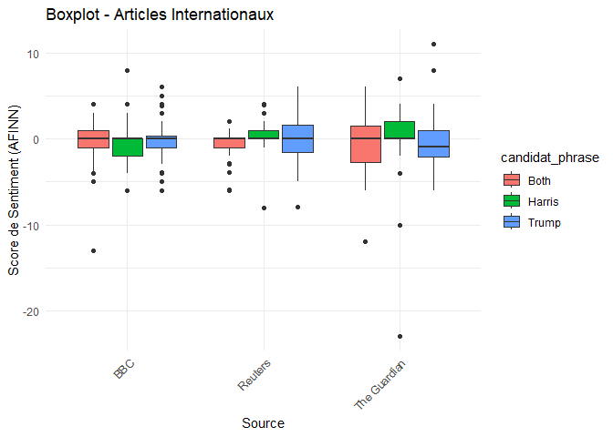

```r
plot_sentiment_boxplot(sentiment_international, "Boxplot - Articles Internationaux")
```

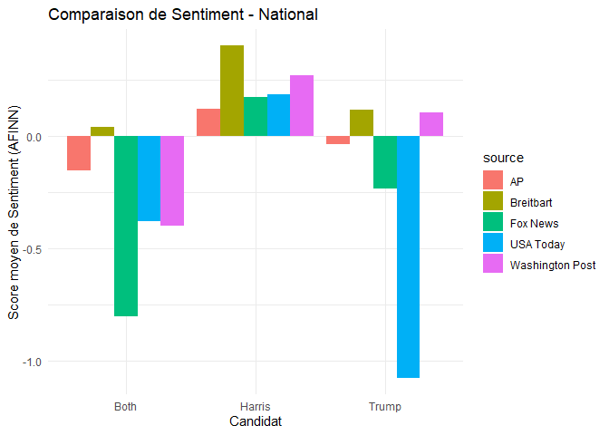

```r
# Barplot pour comparer le sentiment moyen par candidat et par source
plot_comparative_sentiment_barplot <- function(sentiment_data, title = "Comparaison de Sentiment") {
  sentiment_means <- sentiment_data %>%
    group_by(candidat_phrase, source) %>%
    summarise(mean_sentiment = mean(sentiment_afinn))

  ggplot(sentiment_means, aes(x = candidat_phrase, y = mean_sentiment, fill = source)) +
    geom_bar(stat = "identity", position = "dodge") +
    labs(title = title, x = "Candidat", y = "Score moyen de Sentiment (AFINN)") +
    theme_minimal()
}

# Application de la fonction pour chaque arc
plot_comparative_sentiment_barplot(sentiment_national, "Comparaison de Sentiment - National")
```

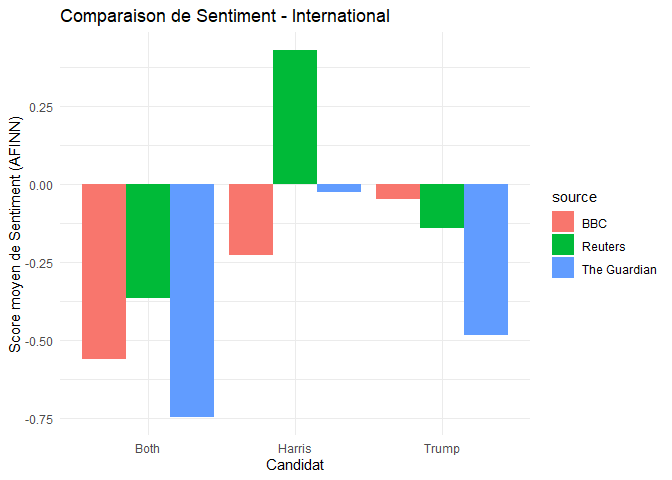

```r
plot_comparative_sentiment_barplot(sentiment_international, "Comparaison de Sentiment - International")
```

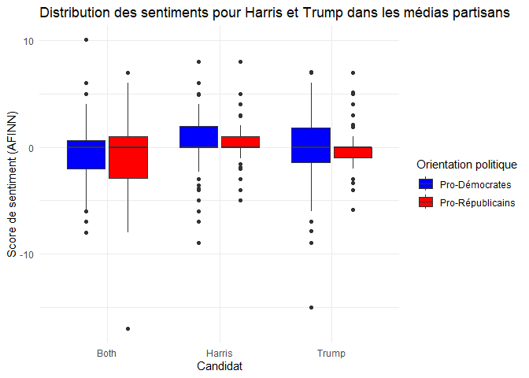

```r
# Boxplot des sentiments pour Harris et Trump dans les articles partisans
ggplot(sentiment_partisan, aes(x = candidat_phrase, y = sentiment_afinn, fill = political_orientation)) +
  geom_boxplot() +
  scale_fill_manual(values = c("Pro-Démocrates" = "blue", "Pro-Républicains" = "red")) +
  labs(
    title = "Distribution des sentiments pour Harris et Trump dans les médias partisans",
    x = "Candidat",
    y = "Score de sentiment (AFINN)",
    fill = "Orientation politique"
  ) +
  theme_minimal()
```

# 5. Analyse et ses résulats

Finalement, cette analyse de la couverture médiatique démontre clairement que les outils utilisés ne sont pas suffisants pour capturer toute la complexité des biais médiatiques. Les modèles actuels peinent à saisir les nuances des articles “neutres” et ne permettent pas d’évaluer de manière critique les choix éditoriaux sous-jacents. Pour affiner cette analyse, il serait judicieux de recourir à des techniques de Machine Learning plus sophistiquées et d’introduire des mesures quantitatives de la variabilité des sentiments au sein même des médias. Cela permettrait de mieux comprendre l’impact réel des biais médiatiques sur l’opinion publique, notamment dans le cadre d’élections.

# 6. Réponse à la Question

# Conclusion

Pour approfondir cette analyse, il serait pertinent de recourir au Topic Modeling afin d’identifier les thèmes dominants dans les articles, offrant ainsi une compréhension plus fine des perceptions des candidats, au-delà des simples mesures de sentiment. L’intégration de modèles de Machine Learning supervisé, spécialement entraînés sur des corpus spécifiques aux médias politiques, permettrait également d’améliorer la précision de l’analyse des sentiments. Enfin, une analyse plus poussée des médias, avec un volume de données accru et en se basant sur les interconnexions entre articles et sources, pourrait révéler des dynamiques plus complexes de diffusion de l’information et de construction des narratifs politiques.